# import 문 – 라이브러리 가져오기

- 다른 사람이 만들어 놓은 코드 묶음(도구)를 불러오는 것
- 그래프, 데이터 분석, 웹 등 다양하게 사용
- as 뒤는 별명

```python
import sympy as sp #수학 기호 계산을 도와주는 라이브러리
import matplotlib.pyplot as plt #그래프를 그려주는 라이브러리
import numpy as np #수치 계산을 도와주는 라이브러리
import pandas as pd #데이터 분석을 도와주는 라이브러리
```

```python
!pip install koreanize_matplotlib # matplotlib에서 한글이 깨지지 않도록 폰트 설정하는 라이브러리
import koreanize_matplotlib
```

```
Downloading koreanize_matplotlib-0.1.1-py3-none-any.whl (7.9 MB)
   ━━━━━━━━━━━━━━━━━━━━━━━━━━━━━━━━━━━━━━━━ 7.9/7.9 MB 38.9 MB/s eta 0:00:00
```

# 1. 출력하기 - print()

- 글자를 화면에 보여줌
- 따옴표는 문자열을 의미

```python
#출력하기

print("안녕")
```

```
안녕
```

```python
print(10)
```

```
10
```

# 2. 변수 만들기 - 값 저장

- = 는 값을 저장한다는 뜻
- name, age 등 변수 이름은 마음대로 정할 수 있음

score = 90 ✅  
score1 = 85 ✅  
_score = 100 ✅  
1score = 90 ❌ 오류 (숫자로 시작)  
total-score = 80 ❌ 오류 (-는 연산자로 인식됨)

```python
name = '서준'
print(name)
```

```
서준
```

```python
age = 17
print(age)
```

```
17
```

# 3. 자료형 (데이터의 종류)

- 자료형에 따라 다르게 다룸

```python
a = 10          #정수(int)
b = 3.14        #실수(float)
c = "hello"     #문자열(str)
d = True        #불리언(bool)
print(type(a))
print(type(b))
print(type(c))
print(type(d))
```

```
<class 'int'>
<class 'float'>
<class 'str'>
<class 'bool'>
```

# 문자열 포맷(f-string)

- 문자열 안에 {}로 변수값을 넣는 방법
- f"..." 형태로 사용

```python
name = "영희"
print(f"{name}님, 안녕하세요!")
```

```
영희님, 안녕하세요!
```

```python
age = 17
print(f"{name}는 {age}살 입니다.")
```

```
영희는 17살 입니다.
```

# 4. 입력받기 - input()

- 사용자가 직접 값을 입력함
- 결과는 항상 "문자열(str)"로 들어옴

```python
name = input("이름을 입력하세요: ")
print(name)
```

```
이름을 입력하세요: 민수
민수
```

```python
name = input("이름을 입력하세요: ")
print(f"{name}님, 안녕하세요!")
```

```
이름을 입력하세요: 민수
민수님, 안녕하세요!
```

# 5. 형 변환 – int(), float(), str()

- input()으로 받은 값은 문자 → 숫자로 바꾸려면 int() 필요

```python
age = input("나이를 입력하세요: ")
print(age)
print(type(age))
```

```
나이를 입력하세요: 17
17
<class 'str'>
```

```python
age = int(input("나이를 입력하세요: "))
print(age)
print(type(age))
```

```
나이를 입력하세요: 17
17
<class 'int'>
```

```python
age1 = input("나이를 입력하세요: ")
age2 = input("나이를 입력하세요: ")
print(age1 + age2)
```

```
나이를 입력하세요: 17
나이를 입력하세요: 18
1718
```

```python
age1 = int(input("나이를 입력하세요: "))
age2 = int(input("나이를 입력하세요: "))
print(age1 + age2)
```

```
나이를 입력하세요: 17
나이를 입력하세요: 18
35
```

# 6. 연산자 – 계산하기

```python
a = 10
b = 3
print(a + b)   # 더하기
print(a - b)   # 빼기
print(a * b)   # 곱하기
print(a / b)   # 나누기 (실수)
print(a // b)  # 나누기 (정수)
print(a % b)   # 나머지
print(a ** b)  # 거듭제곱
```

```
13
7
30
3.3333333333333335
3
1
1000
```

# 연습

- 달러 -> 원화 변환기

```python
# 환율 변수 설정하기
rate = 1424.20

# 금액 float로 입력 받기
usd = float(input("달러를 입력하세요: "))

# 계산
won = usd * rate

# 출력
print(f"{usd}달러는 {won}원 입니다.")
```

```
달러를 입력하세요: 17
17.0달러는 24211.4원 입니다.
```

# 연습

- 수식 $x^3 - 2x + 1$ 을 변수 $y$ 에 저장하고 변수 $y$ 를 프린트 하세요.

```python
x = sp.Symbol('x') # 수학기호로서의 'x'로 만들기

y = x**3-2*x+1

print(y)
```

```
x**3 - 2*x + 1
```

```python
sp.init_printing()  # 수식 예쁘게 출력 준비
display(y)
```

$\displaystyle x^{3} - 2 x + 1$

```python
# 함수의 해 구하기
sp.solve(y)
```

$\displaystyle \left[ 1, \ - \frac{1}{2} + \frac{\sqrt{5}}{2}, \ - \frac{\sqrt{5}}{2} - \frac{1}{2}\right]$

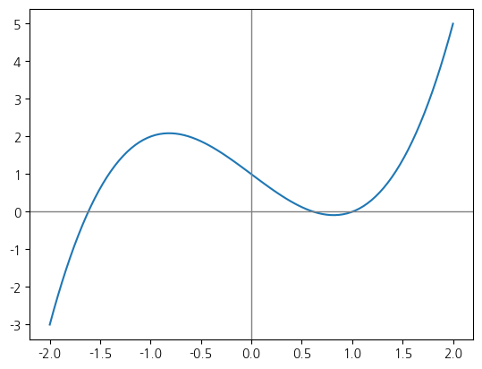

```python
# 그래프 그리기

x = np.linspace(-2, 2, 100)
y = x**3-2*x+1

plt.plot(x, y)

# x=0, y=0 기준선 추가
plt.axhline(0, color='gray', linewidth=1)  # x축, axhline()은 “가로줄”
plt.axvline(0, color='gray', linewidth=1)  # y축, axvline()은 “세로줄”

plt.show()
```

# 연습

- 수식 $x^3 - 6x^2 + 11x - 6$ 을 함수 $y$ 에 저장하고, 함수 $y$ 의 그래프를 그리세요.

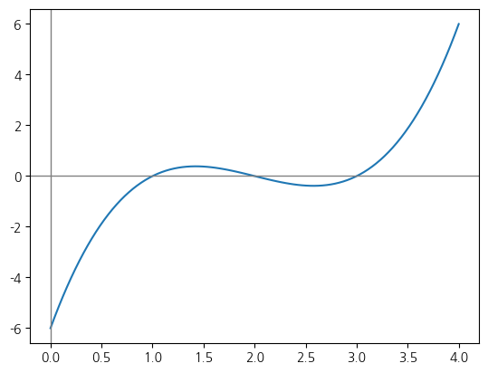

```python
# 그래프 그리기

x = np.linspace(0, 4, 100)
y = x**3-6*x**2+11*x-6

plt.plot(x, y)

# x=0, y=0 기준선 추가
plt.axhline(0, color='gray', linewidth=1)  # x축, axhline()은 “가로줄”
plt.axvline(0, color='gray', linewidth=1)  # y축, axvline()은 “세로줄”

plt.show()
```

# 7. 조건문 – if, else

- 조건에 따라 다른 결과를 출력함
- : 콜론 뒤는 반드시 들여쓰기로 구분!

```python
score = 85
if score >= 90:
    print("A학점")
else:
    print("B학점")
```

```
B학점
```

```python
score = 65
if score >= 90:
    print("A학점")
elif score >= 80:
    print("B학점")
else:
    print("C학점")
```

```
C학점
```

```python
# 점수를 사용자로부터 입력받음
score = float(input("점수를 입력하세요: "))

# 조건문으로 학점 출력
if score >= 90:
    print("A학점")
elif score >= 80:
    print("B학점")
else:
    print("C학점")
```

```
점수를 입력하세요: 85
B학점
```

# 8. 리스트

- 여러 값을 순서대로 저장하는 자료형
- 값에 접근할 때는 colors[0]처럼 인덱스 사용

```python
# 리스트

colors = ["빨강", "초록", "파랑"]
print(colors)
```

```
['빨강', '초록', '파랑']
```

```python
print(colors[0])
```

```
빨강
```

# 9. 딕셔너리

- 이름:값 형태로 저장 {Key:Value}
- 값에 접근할 땐 student["이름"]

```python
student = {"이름": "민수", "점수": 95}
print(student)
print(student["이름"])
```

```
{'이름': '민수', '점수': 95}
민수
```